# Bash & Tricks

## The fun starts here

What can we do with all these (and tons of other) tools?

- Record their output
- Get the error status
- Knit them together to build “pipelines”
- Running them over batches of files

## Input/Ouput/Error streams

POSIX* has 3 standard data streams:

- 0 `STDIN`: Standard Input, can send data to a program
- 1 `STDOUT`: Standard Output, output data from a program
- 2 `STDERR`: Standard Error, errors/warnings from a program

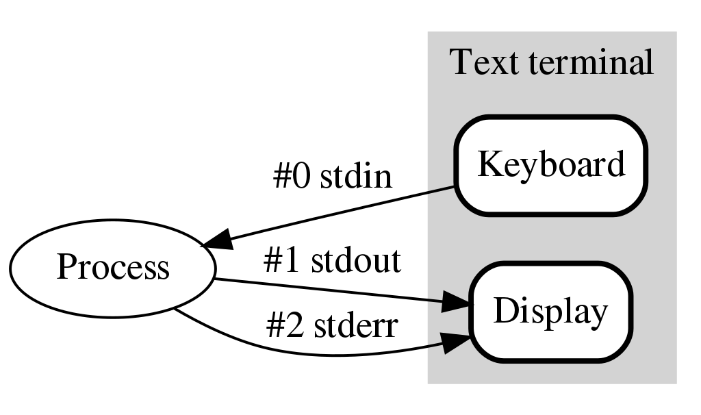

*Portable Operating System Interface: API in Unix

## Redirecting Standard Streams

Streams can be redirected using arrows

- `> filename` Redirects STDOUT (`>>` appends)
- `< filename` Redirects STDIN
- `2> filename` Redirects STDERR
- `2>&1` Sends STDERR to STDOUT results in one output stream
- `> /dev/null` Sends output to the data Nirvana

```bash
$ ls -1 *.fastq.gz > fastq_list.txt
$ cat fastq_list.txt
sample_1.fastq.gz
sample_2.fastq.gz
[...]

$  program sample_1.fastq.gz > result.txt 2> error.txt
$  program sample_1.fastq.gz > result.txt 2>&1
```

## Pipes

This is the Unix philosophy:

- Write programs that do one thing and do it well
- Write programs to work together
- Write programs to handle text streams, because that is a universal interface.

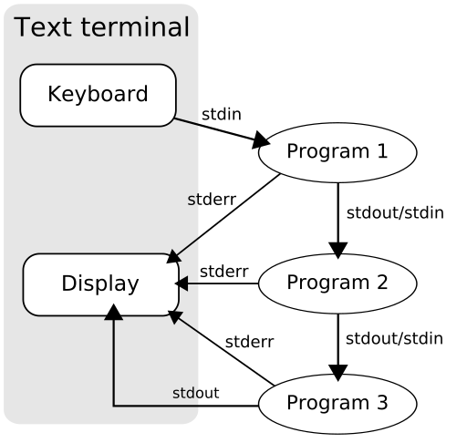

`$ cat file.txt | grep -v "^$" | sort k2,2n`

`$ grep ">" seq.fasta | tr -d ">" > out.txt`

`$ cat seq.fasta | rev | tr "ACGT" "TGCA" > rev_comp.fasta`

## Named pipes

Named pipes also known as *FIFO*:

- *F*irst *I*n, *F*irst *O*ut principle
- extension for traditional pipe concept
- in contrast to unnamed pipes they use the filesystem
- `mkfifo` creates the FIFO
- do not consume disk space

Two separate processes can access the pipe by name one process can open it as a **reader**, and the other as a **writer**.

## Named pipes example

```bash
$ mkfifo R1
$ mkfifo R2
$ yara_mapper -e 3 -t 4 -f bam y_idx reads_R1.fq reads_R2.fq | \
    samtools view -@ 4 -h -F 4 -b1 | \
    tee R1 R2 > /dev/null &
    samtools view -@ 2 -h -f 0x40 -b1 R1 > mapped_1.bam &
    samtools view -@ 2 -h -f 0x80 -b1 R2 > mapped_2.bam &
wait
rm -f R1 R2
```

`tee` reads standard input and writes it to both standard output and one or more files, effectively duplicating its input

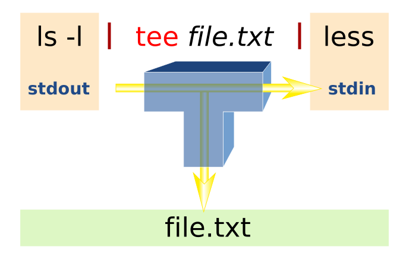

## System / Process monitoring

- `ps`
  - Show all processes:  
    `ps -e`
  - Show all processes for `$USER` in full format as tree:  
    `ps -efxu`
  - Show all processes for all users in full format as tree:  
    `ps -afxu`
- Continuous monitoring:
  - `top`, `atop`, `htop`, or `glances`
- Disk usage:
  - `du`, `du -h -d <N>`, `du -sh`
  - `spacereporter` (only on CePH)

## Process management

- Abort the current process: `<CTRL>+<c>`
- Stop the current process: `<CTRL>+<z>`
- Send job to the background  
  `bg [jobspec]`
- Bring job to the foreground and make it current  
  `fg [jobspec]`
- List jobs in current background  
  `jobs`
- Run job in background:  
  `samtools sort -o sorted.bam unsorted.bam > sort.log 2>&1 &`  
  or if you want the job to continue even if you close the shell  
  `nohup samtools sort -o sorted.bam unsorted.bam > sort.log 2>&1 &`  
  use `disown <PID>` if you forgot `nohup`

## Process management

- Send a signal to a process `kill [-signal] <PID>`
  - e.g. `-TERM`, `-KILL`, `-STOP`, `-CONT`
- Use the `k` key in `top` or `atop` to send a signal to a selected process
- Use `<F9>` to send signal to selected processes in `htop`
- Kill all processes by name
  - `killall <processname>`
  - `killall -i <processname>`

*Note*:  
A user may only kill processes the s*he owns, only root can kill all processes

## Loops

```bash
for value in {5,10,20,50}
  do
    run_simulation --iterations=$value > ${value}_iterations.log 2>&1
  done

for value in {10..100}
  do
    run_simulation --iterations=$value > ${value}_iterations.log 2>&1
  done

for file in *txt
  do
    echo $file
    grep .sam $file | wc -l
  done
```

If you need to use loops, consider switching straight to **nextflow** instead (later lecture!)

## tmux

`tmux` is a terminal multiplexer

- You can start a `tmux` session
  - open multiple windows inside a session
  - split into rectangular panes.
- With `tmux` it is easy to switch between multiple programs in one terminal
- sessions may be detached and reattached to a different terminal
- `tmux` sessions are persistent

All commands in Tmux start with a prefix, which by default is `<CTRL>+b`.

## tmux

Basic `tmux` commands

```bash
$ tmux new -s <session_name>
```

`<CTRL>+b c` Create a new window (with shell)  
`<CTRL>+b w` Choose window from a list  
`<CTRL>+b ,` Rename the current window  
`<CTRL>+b %` Split current pane horizontally into two panes  
`<CTRL>+b "` Split current pane vertically into two panes `<CTRL>+b o` Go to the next pane  
`<CTRL>+b ;` Toggle between the current and previous pane  
`<CTRL>+b x` Close the current pane

List and attach `tmux` sessions

```bash
$ tmux ls
$ tmux a -t <session_name>
```

## Setting up passwordless authentication for ssh

- Generate a key pair:
  - private key: stays on your computer
  - public key: put it on the server

Using the public key the server can check that a request comes from your computer.

```bash
# generate a key pair
ssh-keygen

# copy the key pair on the server
ssh-copy-id user@zeus
```

## Other resources

- https://www.bioinformatics.babraham.ac.uk/training/Linux%20bootcamp/Linux%20Bootcamp%20Lectures.pdf
- [Learn Bash in Y minutes](https://learnxinyminutes.com/docs/bash/)